# Stable Isotope Analysis

Masumbuko Semba and Nyamisi Peter

On 10 August, 2018 at 12:36:52.376

# Step 1: Loading the Data

The first step involved loading the data into R workspace. Wickham and Bryan (2018) developed *readxl* package that can read Microsoft Excel Spreadsheet directly from the local machine. The sheet number three that contains isotopic data was imported from the local machine into the workspace of [R](https://www.r-project.org/)—a free and open source software for statistical, computation, analysis and graphics (R Core Team 2018)

Table 1: Overview of Isotopes

| Identifier 1 | d13C | d15N | Habitat/site | Species | SpeciesName |
| --- | --- | --- | --- | --- | --- |
| H10 | -19.958 | 6.640 | MB1 | BENTHOS | Benthos |
| H11 | -20.067 | 6.276 | MB1 | BENTHOS | Benthos |
| A5 | -16.912 | 1.701 | MB2 | BENTHOS | Benthos |
| A6 | -16.656 | 1.366 | MB2 | BENTHOS | Benthos |
| A11 | -23.898 | 4.299 | MB3 | BENTHOS | Benthos |
| A12 | -23.943 | 4.267 | MB3 | BENTHOS | Benthos |
| H7 | -24.081 | 2.110 | MB1 | BROWN ALGAE | Brown algae |
| H8 | -18.584 | 2.760 | MB1 | BROWN ALGAE | Brown algae |
| A3 | -27.961 | 0.353 | MB2 | BROWN ALGAE | Brown algae |
| A4 | -22.067 | 0.911 | MB2 | BROWN ALGAE | Brown algae |
| A7 | -29.090 | 0.656 | MB3 | BROWN ALGAE | Brown algae |
| A8 | -28.598 | 0.429 | MB3 | BROWN ALGAE | Brown algae |
| F2 | -23.085 | 1.705 | KMG3 | BROWN ALGAE (SOIL) | Brown algae |
| F3 | -21.363 | 1.489 | KMG3 | BROWN ALGAE (SOIL) | Brown algae |
| A11 | -15.980 | 4.233 | SGK | BROWN ALGAE1 | Brown algae |
| B11 | -20.879 | 6.264 | KMG1 | BROWN ALGAE1 | Brown algae |
| A12 | -15.152 | 4.457 | SGK | BROWN ALGAE2 | Brown algae |
| B12 | -18.729 | 6.387 | KMG1 | BROWN ALGAE2 | Brown algae |
| B1 | -16.152 | 3.420 | SGK | BROWN ALGAE3 | Brown algae |
| D8 | -22.276 | 1.062 | KMG2 | BROWN1 SOIL | Brown algae |
| D9 | -24.125 | 4.094 | KMG2 | BROWN2 SOIL | Brown algae |
| D10 | -26.493 | 4.826 | KMG2 | BROWN3 WASHED | Brown algae |
| D11 | -25.289 | 2.973 | KMG2 | BROWN4 WASHED | Brown algae |
| E6 | -11.370 | 4.581 | KMG2 | GREEN 2 | Green algae |
| F6 | -15.613 | 2.443 | SGK | GREEN ALGAE | Green algae |
| F7 | -17.683 | 2.897 | SGK | GREEN ALGAE | Green algae |
| F8 | -16.851 | 3.212 | SGK | GREEN ALGAE | Green algae |
| A8 | -22.805 | 4.026 | SGK | GREEN ALGAE1 | Green algae |
| C2 | -21.821 | 4.796 | KMG1 | GREEN ALGAE1 | Green algae |
| A9 | -16.348 | 3.864 | SGK | GREEN ALGAE2 | Green algae |
| C3 | -21.939 | 4.332 | KMG1 | GREEN ALGAE2 | Green algae |
| A10 | -20.924 | 4.968 | SGK | GREEN ALGAE3 | Green algae |
| C4 | -21.898 | 3.992 | KMG1 | GREEN ALGAE3 | Green algae |
| E11 | -21.355 | 2.299 | KMG3 | GREEN1 | Green algae |
| E12 | -20.962 | 3.633 | KMG3 | GREEN2 | Green algae |
| F1 | -20.139 | 1.483 | KMG3 | GREEN3 | Green algae |
| A4 | -24.329 | 6.443 | SGK | PHY1 | Phytoplankton |
| D1 | -24.197 | 3.066 | KMG2 | PHY1 | Phytoplankton |
| E7 | -24.912 | 0.851 | KMG3 | PHY1 | Phytoplankton |
| B9 | -24.706 | 4.279 | KMG1 | PHY2 | Phytoplankton |
| D2 | -23.930 | 2.943 | KMG2 | PHY2 | Phytoplankton |
| E8 | -24.806 | 2.377 | KMG3 | PHY2 | Phytoplankton |
| A6 | -13.179 | 4.631 | SGK | PHY3 | Phytoplankton |
| B10 | -24.696 | 4.047 | KMG1 | PHY3 | Phytoplankton |
| D3 | -23.967 | 4.564 | KMG2 | PHY3 | Phytoplankton |
| A7 | -13.260 | 3.654 | SGK | PHY4 | Phytoplankton |
| H1 | -19.241 | 3.178 | MB SEA | PHYTO | Phytoplankton |
| H12 | -26.056 | 3.283 | MB2 | PHYTO | Phytoplankton |
| B1 | -28.575 | 0.190 | MB3 | PHYTO | Phytoplankton |
| D12 | -22.773 | 0.923 | KMG2 | SNAIL | Snail |
| H4 | -22.669 | 1.110 | MB1 | SNAIL | Snail |
| H6 | -25.354 | 1.505 | MB1 | SNAIL | Snail |
| A1 | -25.692 | 0.537 | MB2 | SNAIL | Snail |
| A2 | -21.560 | 0.417 | MB2 | SNAIL | Snail |
| E1 | -20.329 | 2.488 | KMG2 | SNAIL (LEAVES) | Snail |
| E2 | -23.306 | 2.642 | KMG2 | SNAIL (LEAVES) | Snail |
| E3 | -22.462 | 1.749 | KMG2 | SNAIL (TRUNK) | Snail |
| E4 | -23.920 | 0.857 | KMG2 | SNAIL (TRUNK) | Snail |
| C8 | -20.454 | 1.141 | KMG1 | SNAIL1 | Snail |
| F4 | -24.946 | 0.631 | KMG3 | SNAIL1 | Snail |
| C9 | -24.786 | 0.968 | KMG1 | SNAIL2 | Snail |
| C10 | -22.328 | 2.151 | KMG1 | SNAIL3 | Snail |
| B5 | -25.171 | 3.559 | SGK | ZOO1 | Zooplankton |
| C5 | -24.432 | 4.241 | KMG1 | ZOO1 | Zooplankton |
| D5 | -25.157 | 5.576 | KMG2 | ZOO1 | Zooplankton |
| B6 | -25.103 | 3.410 | SGK | ZOO2 | Zooplankton |
| C6 | -24.637 | 4.474 | KMG1 | ZOO2 | Zooplankton |
| D6 | -24.783 | 4.022 | KMG2 | ZOO2 | Zooplankton |
| E10 | -24.534 | 3.642 | KMG3 | ZOO2 | Zooplankton |
| B7 | -24.666 | 3.380 | SGK | ZOO3 | Zooplankton |
| C7 | -24.350 | 5.781 | KMG1 | ZOO3 | Zooplankton |
| D7 | -24.990 | 1.323 | KMG2 | ZOO3 | Zooplankton |

Table 2: Summary statistics of the six common species

| SpeciesName | n | percentage |
| --- | --- | --- |
| Brown algae | 17 | 23.61 |
| Green algae | 13 | 18.06 |
| Phytoplankton | 13 | 18.06 |
| Snail | 13 | 18.06 |
| Zooplankton | 10 | 13.89 |
| Benthos | 6 | 8.33 |

# Step 2: Getting the data into simmr

Once we have the dataset in the workspace, we have to tidy in the format that *simmr* package understand (Wickham and Henry 2018) . This is because simmr requires at minimum 3 input objects; the *mixtures*, the *source* means, and the source *standard deviations* as matrix (Parnell 2016).

> Optionally, you can also add correction data (also called trophic enrichment factors, TEFs) represented again as means and standard deviations, and concentration dependence values.

The created mix object contains the stable isotopic data for the consumers. The matrix function was used to turn this into a matrix (a rectangle of numbers) with 2 columns. The first column contains the data for isotope 1, and the second the data for isotope 2.

The source names was created in the s_names object, and the source means and standard deviations in s_means and s_sds were computed and converted to matrix format, where the number of rows is the number of species and column represent the mean and standard deviation of the isotopes.

# Step 3: Plotting the data in iso-space

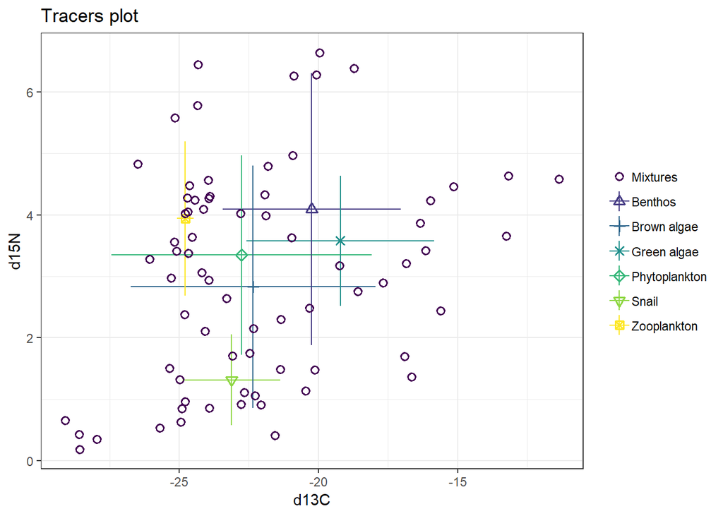

Figure 1

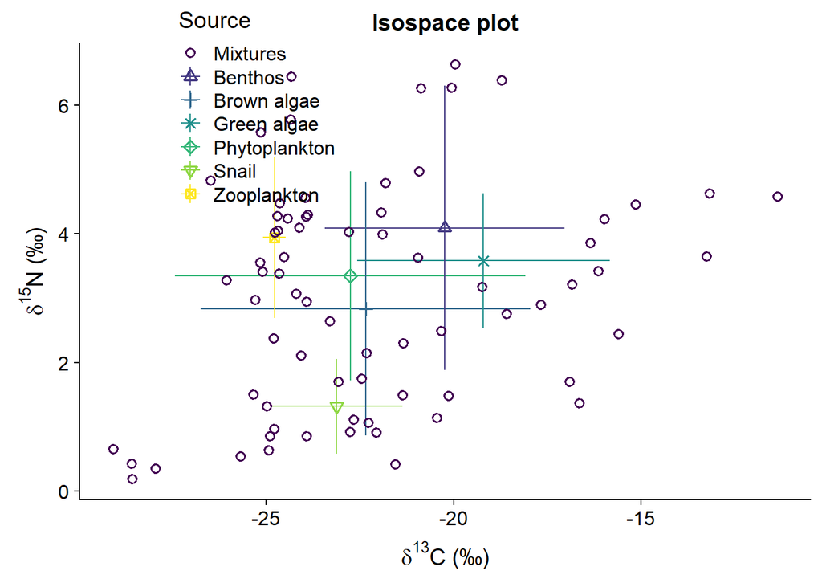

Figure 1

# Step 4: running simmr

The next step is to actually run the model.This command takes the object *simmr_in* we created earlier and uses it as input for the model. It tells simmr to store the output from the model run in an object called simmr_out. This is achieved with the command:

Markov chain Monte Carlo (MCMC) works by repeatedly guessing the values of the dietary proportions and find those values which fit the data best. The initial guesses are usually poor and are discarded as part of an initial phase known as the burn-in. Subsequent iterations are then stored and used for the posterior distribution; the best estimates of the dietary proportions given the data and the model. Because it can take many thousands of iterations to move away from the initial guesses, convergence diagnostics can be created to check the model has run properly. In simmr this is done with:

```
Gelman diagnostics - these values should all be close to 1.
If not, try a longer run of simmr_mcmc.
              Point est. Upper C.I.
Benthos                1       1.01
Brown algae            1       1.01
Green algae            1       1.01
Phytoplankton          1       1.00
Snail                  1       1.00
Zooplankton            1       1.01
sd_d13C                1       1.00
sd_d15N                1       1.01
```

# Step 5: exploring the model results

simmr produces both textual and graphical summaries of the model run. Starting with the textual summaries, we can get tables of the means, standard deviations and credible intervals (the Bayesian equivalent of a confidence interval) with:

```
               mean    sd
Benthos       0.128 0.094
Brown algae   0.272 0.214
Green algae   0.126 0.087
Phytoplankton 0.207 0.171
Snail         0.151 0.094
Zooplankton   0.117 0.082
sd_d13C       3.119 0.735
sd_d15N       1.459 0.296
```

```
               2.5%   25%   50%   75% 97.5%
Benthos       0.014 0.055 0.104 0.180 0.360
Brown algae   0.020 0.094 0.207 0.411 0.762
Green algae   0.014 0.058 0.106 0.176 0.342
Phytoplankton 0.017 0.074 0.155 0.298 0.648
Snail         0.017 0.074 0.140 0.214 0.359
Zooplankton   0.013 0.054 0.099 0.163 0.317
sd_d13C       1.089 2.818 3.254 3.589 4.191
sd_d15N       0.635 1.341 1.502 1.643 1.915
```

simmr can also produce histograms, boxplots, density plots, and matrix plots of the output. Starting with the density plot:

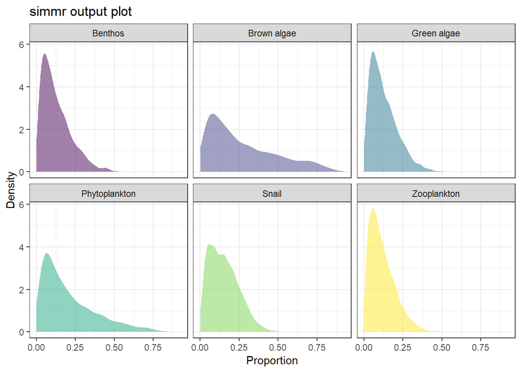

Figure 2

The most useful output plot is the matrix plot

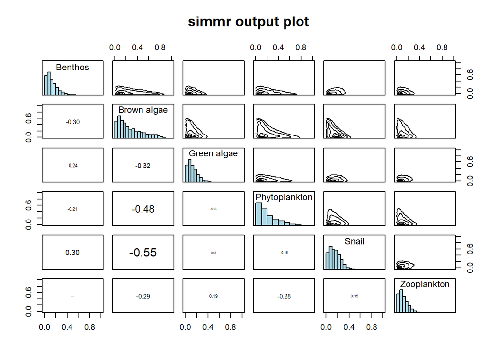

Figure 3

This shows the source histograms on the diagonal, contour plots of the relationship between the sources on the upper diagonal, and the correlation between the sources on the lower diagonal. Large negative correlations indicate that the model cannot discern between the two sources; they may lie close together in iso-space. Large positive correlations are also possible when mixture data lie in a polygon consisting of multiple competing sources.

If you want to compare the dietary proportions between two different sources, you can use the compare_sources function. This takes two or more sources and compares the dietary proportions with an optional plot. For example:

```
Prob ( proportion of Brown algae > proportion of Green algae ) = 0.672
```

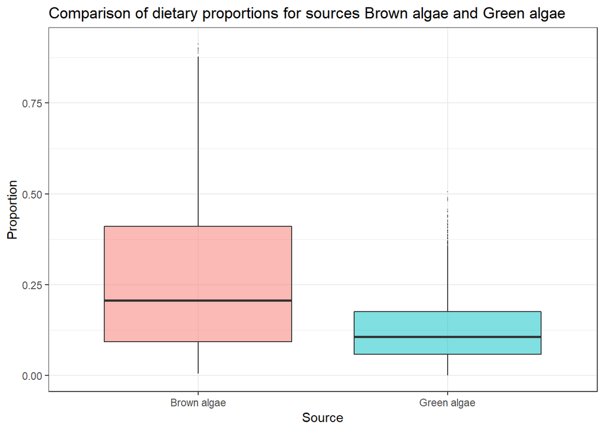

Figure 4

```
Prob ( proportion of Phytoplankton > proportion of Zooplankton ) = 0.622
```

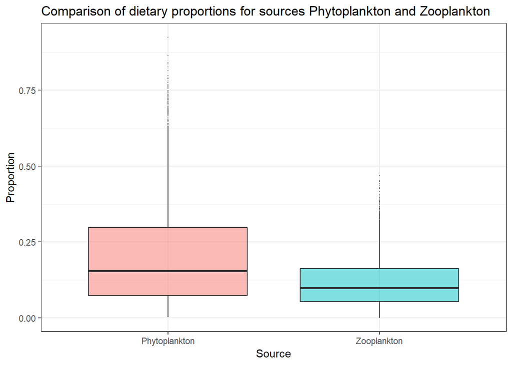

Figure 5

```
Prob ( proportion of Benthos > proportion of Snail ) = 0.416
```

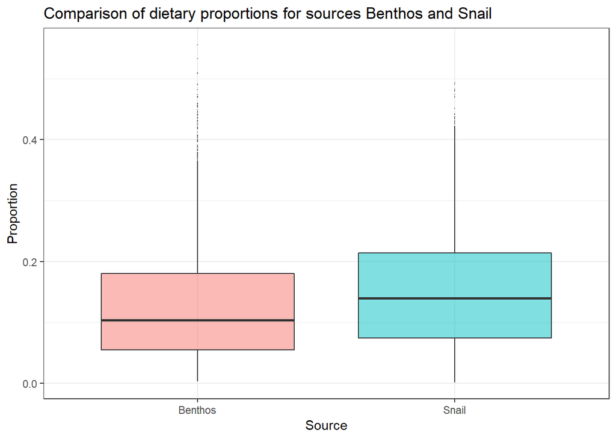

Figure 6

This produces a direct probability that the dietary proportion for the first source is bigger than that of the second. If you want to compare more than two sources, specify them with:

```
Most popular orderings are as follows:
Brown algae > Phytoplankton > Green algae > Zooplankton > Snail > Benthos
                                                                   0.0072
Brown algae > Phytoplankton > Benthos > Snail > Zooplankton > Green algae
                                                                   0.0070
Brown algae > Zooplankton > Phytoplankton > Green algae > Benthos > Snail
                                                                   0.0068
Phytoplankton > Brown algae > Green algae > Snail > Zooplankton > Benthos
                                                                   0.0062
Brown algae > Phytoplankton > Benthos > Green algae > Snail > Zooplankton
                                                                   0.0058
Brown algae > Phytoplankton > Benthos > Snail > Green algae > Zooplankton
                                                                   0.0058
Brown algae > Phytoplankton > Zooplankton > Green algae > Snail > Benthos
                                                                   0.0058
Phytoplankton > Brown algae > Benthos > Snail > Zooplankton > Green algae
                                                                   0.0055
Phytoplankton > Brown algae > Snail > Green algae > Benthos > Zooplankton
                                                                   0.0055
Phytoplankton > Snail > Benthos > Green algae > Zooplankton > Brown algae
                                                                   0.0055
Phytoplankton > Snail > Green algae > Zooplankton > Benthos > Brown algae
                                                                   0.0055
Brown algae > Phytoplankton > Green algae > Snail > Benthos > Zooplankton
                                                                   0.0052
Brown algae > Phytoplankton > Snail > Green algae > Benthos > Zooplankton
                                                                   0.0052
Phytoplankton > Benthos > Snail > Zooplankton > Brown algae > Green algae
                                                                   0.0052
Phytoplankton > Brown algae > Benthos > Snail > Green algae > Zooplankton
                                                                   0.0052
Brown algae > Benthos > Phytoplankton > Green algae > Snail > Zooplankton
                                                                   0.0050
Brown algae > Green algae > Snail > Zooplankton > Phytoplankton > Benthos
                                                                   0.0050
Brown algae > Phytoplankton > Snail > Zooplankton > Benthos > Green algae
                                                                   0.0050
Brown algae > Snail > Benthos > Green algae > Zooplankton > Phytoplankton
                                                                   0.0050
Phytoplankton > Benthos > Brown algae > Snail > Zooplankton > Green algae
                                                                   0.0050
Phytoplankton > Snail > Benthos > Green algae > Brown algae > Zooplankton
                                                                   0.0050
Brown algae > Benthos > Phytoplankton > Snail > Green algae > Zooplankton
                                                                   0.0048
Brown algae > Benthos > Phytoplankton > Snail > Zooplankton > Green algae
                                                                   0.0048
Brown algae > Benthos > Snail > Phytoplankton > Zooplankton > Green algae
                                                                   0.0048
Brown algae > Green algae > Phytoplankton > Snail > Zooplankton > Benthos
                                                                   0.0048
Brown algae > Phytoplankton > Benthos > Green algae > Zooplankton > Snail
                                                                   0.0048
Brown algae > Phytoplankton > Green algae > Benthos > Zooplankton > Snail
                                                                   0.0048
Brown algae > Phytoplankton > Snail > Benthos > Green algae > Zooplankton
                                                                   0.0048
Brown algae > Zooplankton > Benthos > Snail > Phytoplankton > Green algae
                                                                   0.0048
Phytoplankton > Snail > Benthos > Brown algae > Green algae > Zooplankton
                                                                   0.0048
```

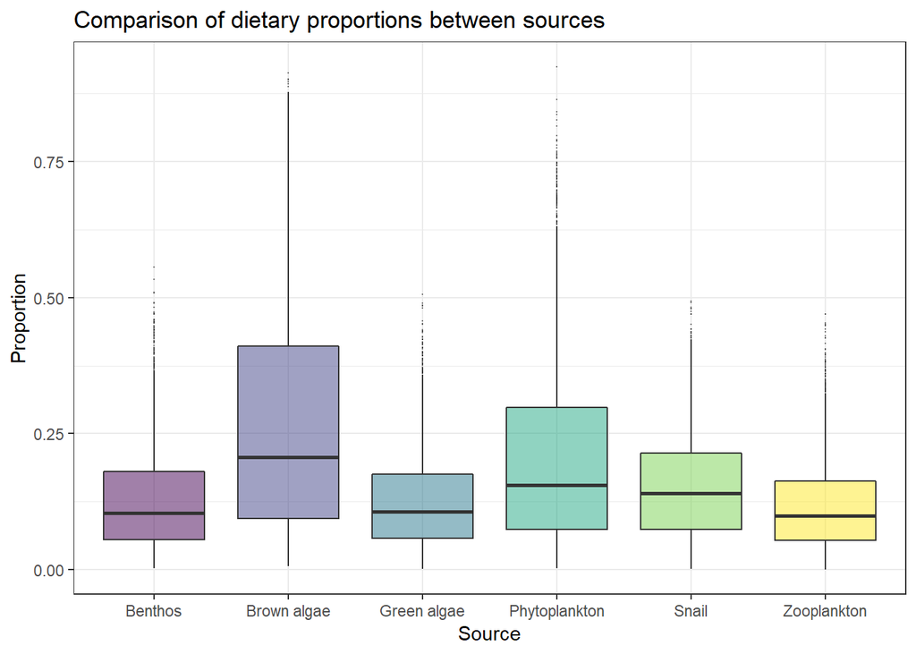

Figure 7

# Reference

Parnell, Andrew. 2016. *Simmr: A Stable Isotope Mixing Model*. https://CRAN.R-project.org/package=simmr.

R Core Team. 2018. *R: A Language and Environment for Statistical Computing*. Vienna, Austria: R Foundation for Statistical Computing. https://www.R-project.org/.

Wickham, Hadley, and Jennifer Bryan. 2018. *Readxl: Read Excel Files*. https://CRAN.R-project.org/package=readxl.

Wickham, Hadley, and Lionel Henry. 2018. *Tidyr: Easily Tidy Data with ’Spread()’ and ’Gather()’ Functions*. https://CRAN.R-project.org/package=tidyr.